# Proyectos de R, organizando la mesa de Trabajo

Buenas prácticas para organizar un proyecto de trabajo con datos

[🔗 Estación R](https://estacion-r.netlify.app/)

2026-09-24

# Bienvenidos y bienvenidas a Estación R

💬 [Slack](https://join.slack.com/t/estacion-r/shared_invite/zt-2cktmesg3-11HhUxMFmynQe18ZsBkVpA)

🔗 [Web](https://estacion-r.netlify.app/)

🐘 [Mastodon](https://botsin.space/@r_tips)

𝕏 [X](https://twitter.com/estacion_erre)

✉️ Correo

[Instagram](https://www.instagram.com/estacion_ere?igsh=OWhtcWR5ZGkwb3Bw&utm_source=qr)

[LinkedIn](https://www.linkedin.com/company/estacion-r/)

## ¿Qué vimos?

✅ Valores

✅ Vectores

✅ Data frames

✅ Objetos

✅ Funciones

## Hoja de Ruta

📌 Paquetes

📌 Ruta de un archivo (o *file path*)

📌 Importar nuestra primera base de datos

📌 Armar un proyecto de trabajo en Rstudio (*R project*)

📌 Estructura de carpeta

```
  👉🏼 Cómo estructurar la carpeta de trabajo

  👉🏼 Cómo nombrar archivos
```

# Paquetes

## Paquetes

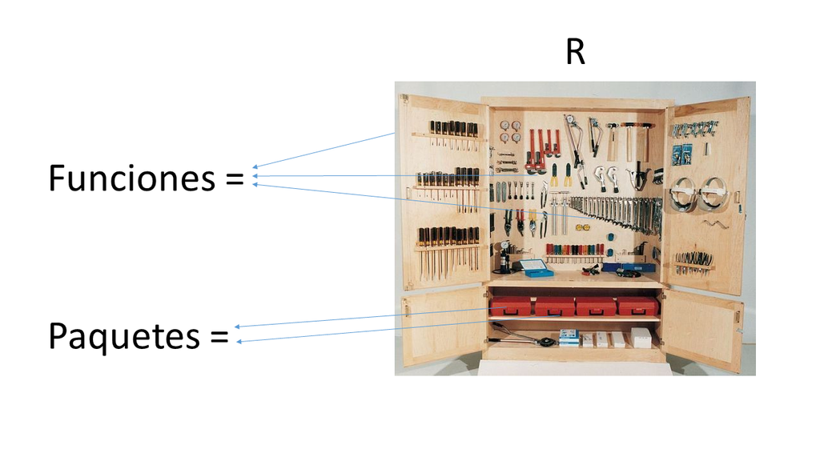

## Paquetes

- Los paquetes o librerías son la potencia de los lenguajes como R y Python
- Es cómo las comunidades pueden hacer crecer al lenguaje

[figure not shown]

[Link a Mapa de paquetes](https://anatomyofcode.com/cranmap/)

## Paquetes

> Se **instala** (una vez por computadora)

```r
install.packages("nombre_del_paquete")
```

> Se **convoca** (por cada sesión de R)

```r
library(nombre_del_paquete)
```

## Paquetes

> Para *instalar* un paquete (`install.packages()`), el nombre del paquete va **siempre** entre comillas

```r
install.packages("readr")
```

## Paquetes

> Para *instalar* un paquete (`install.packages()`), el nombre del paquete va **siempre** entre comillas

```r
install.packages("readr")
```

> Para *convocar* un paquete (`library()`) el nombre puede o no llevar comillas (se recomienda **sin**)

```r
library(readr)
```

## Paquetes

- Instalemos nuestro primer paquete:

```r
install.packages("readr")
```

## Paquetes

- Instalemos nuestro primer paquete:

```r
install.packages("readr")
```

- ¿Mucha letra roja?

## Paquetes

- Convoquemos al paquete

```r
library(readr)
```

[figure not shown]

# Ruta de archivos

- **Definición:** Ubicación de una carpeta / archivo en mi computadora
- **Máxima:** Todas las carpetas en nuestra computadora tienen una *ruta*

## Ruta de archivos

- **Ejemplo diario de seleccionar una *ruta de archivo*:**

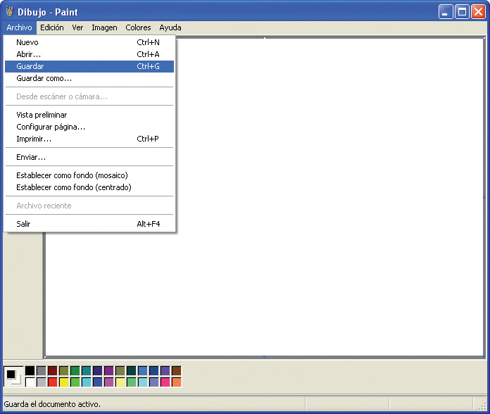

## Importar datos

- Vamos a descargar una base de datos y ubicarla en una carpeta conocida de mi computadora.
- **Base de datos:** *Nombre de Personas. Argentina, año 2015.*

> [Link](https://drive.google.com/file/d/1uyvbLLzvr2qbjIv33XokxmdUJNK26i8b/view?usp=sharing)

## Importar datos

- Vamos a descargar una base de datos y ubicarla en una carpeta conocida de mi computadora.

**- Base de datos:** *Nombre de Personas. Argentina, año 2015.*

[Link](https://drive.google.com/file/d/1uyvbLLzvr2qbjIv33XokxmdUJNK26i8b/view?usp=sharing)

- Tip: Reconocer la *extensión* del archivo a descargar (.csv, .txt, .sav, .dta, .sas, etc.)

## Importar datos

- Manos a la obra:

```r
library(readr)

read_csv(file = "C:/Users/Federico/Downloads/nombres-2015.csv")
```

## Importar datos

- Falta algo…

## Importar datos

- Falta algo…

```r
base_personas <- read_csv(file = "C:/Users/Federico/Downloads/nombres-2015.csv")
```

# Descanso

`10:00`

# Proyectos de trabajo

[figure not shown]

## Proyectos de trabajo

- Copiar la siguiente sentencia en tu consola o script y ejecutar:

```r
base_personas <- read_csv(file = "C:/Users/Federico/Downloads/nombres-2015.csv")
```

## Proyectos de trabajo

- Si compartimos el script a otra persona, **el código se rompe**
- Si cambiamos de computadora, **el código se rompe**
- Si cambiamos la base de lugar, **el código se rompe**

# La solución

[figure not shown]

## Crear un proyecto de Rstudio

- Paso 1:

–> **File (*archivo*) –> New Project (*Nuevo Proyecto…*)**

[figure not shown]

## Crear un proyecto de Rstudio

- Paso 2:

–> **New Directory (*Nueva carpeta*)**

[figure not shown]

## Crear un proyecto de Rstudio

- Paso 3:

–> **New Project**

[figure not shown]

## Crear un proyecto de Rstudio

- Resultado:

[figure not shown]

# Manos a la obra

## Crear un proyecto de Rstudio

- Asegurarse que estamos en el proyecto, de lo contrario, abrirlo

## Crear un proyecto de Rstudio

- Asegurarse esta en el proyecto, de lo contrario, abrirlo ✅
- Crear una carpeta nueva llamada `datos`

## Crear un proyecto de Rstudio

- Asegurarse esta en el proyecto, de lo contrario, abrirlo ✅
- Crear una carpeta nueva llamada `datos` ✅
- Guardar la base de personas en la carpeta `datos`

## Crear un proyecto de Rstudio

- Asegurarse esta en el proyecto, de lo contrario, abrirlo ✅
- Crear una carpeta nueva llamada `datos` ✅
- Guardar la base de personas en la carpeta `datos` ✅
- Ejecutar la siguiente sentencia:

```r
library(readr)

base_personas <- read_csv("datos/nombres-2015.csv")
```

## Crear un proyecto de Rstudio

- **Antes** *(sin un proyecto)*

```r
base_personas <- read_csv(file = "C:/Users/Federico/Downloads/nombres-2015.csv")
```

## Crear un proyecto de Rstudio

- **Antes** *(sin un proyecto)*

```r
base_personas <- read_csv(file = "C:/Users/Federico/Downloads/nombres-2015.csv")
```

- **Después** *(con un proyecto)*

```r
base_personas <- read_csv("datos/nombres-2015.csv")
```

## Estructura de carpetas

- 📂 nuevo_proyecto

[figure not shown]

  - *nuevo_proyecto.Rproj*
  - 📂 datos
    - ⛁ *nombres-2015.csv*
  - 📂 outputs
  - 📂 scripts
    - 📄 *1_levantar_datos.R*
  - 📂 docs_metodologicos
    - 📚 *bibliografia.docx*

[figure not shown]

[🔗 Introducción al Procesamiento de Datos con R](https://pablotis.github.io/intro-r-quarto/)